# Decoding the dynamic TF activity during HSC formation

### 1. Introduction

In this case study, we systemically estimated the dynamic TF activity during HSC formation. We use the single-cell RNA-seq data download from [Hou et.al. 2020](https://www.nature.com/articles/s41422-020-0300-2)

#### 1.1 loading data

The single-cell RNA-seq data of endothelial cells (ECs) were firstly downloaded from GEO, and then we only choose three cell populations for further analysis (including early-AECs, late-AECs, and HECs). The TF activity analysis were performed using the standard **metaRegulon** pipelines except that the `06_endothelial_cells.txt.gz` were used as prior-network. Moreover, the pseudotime information of each single-cell were obtained directly from original paper. Here we start with the analysis steps from TF activity matrix, which can be download from [Zenodo](https://doi.org/10.5281/zenodo.6394068).

Firstly, we need to load the `SingleCellExperiment` object that generated from `metaRegulon()` function.

```r
suppressMessages(suppressWarnings(library(scATFR)))
suppressMessages(suppressWarnings(library(metaRegulon)))
atfr <- readRDS("D:/HSC_Autophagy/Markdown/5.metaRegulon/metaRegulon/inst/extdata/EHT/atfr.rds")
```

#### 1.2 Confirming the cell paths from pseudotime analysis output

One of the most important steps of dynamic TF activity analysis is to identify cell paths from your single-cell RNA-seq data after pseudotime analysis (e.g Monocle). In this study, we just get this information from original paper. Therefore, we first take a look at the pseudotime path from the paper.

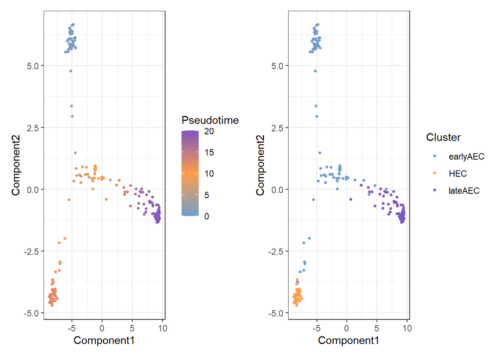

```r
cell_anno <- as.data.frame(colData(atfr))
library(RColorBrewer)
cols <- rev(brewer.pal(9, "YlGnBu"))
cols <- c("#729ece","#ff9e4a","#7e57c2")
pal <- colorRampPalette(cols)(100)
library(ggplot2)
p <- ggplot(data = cell_anno, mapping = aes(x = Component1, y = Component2, color=Pseudotime))+
  geom_point(shape=16, size=1)+
  theme_bw()+
  scale_color_gradientn(colours = pal)
q <- ggplot(data = cell_anno, mapping = aes(x = Component1, y = Component2, color=Cluster))+
  geom_point(shape=16, size=1)+
  theme_bw()+
  scale_color_manual(values = cols)
p+q
```

We can see that there are two paths in above result (earlyAEC to HEC and earlyAEC to lateAEC). However, we found that the cell trajectory is a continuous state and some cells may be in transition state. Next, we identified the cell at the branch point in above two paths and generated the pseudotime weight matrix:

```r
pseudotime_list <- readRDS("D:/HSC_Autophagy/Markdown/5.metaRegulon/metaRegulon/inst/extdata/EHT/cell_weight_pseudotime.rds")
cell_weight <- pseudotime_list$weight
cell_pseudotime <- pseudotime_list$pseudotime
```

The `cell_weight` indicate the cells belong to which path and the `cell_pseudotime` have the pseudotime value of each cell in corresponding path.

### 2. Differential activity analysis between two paths

In this section, we perform differential analysis on TFs at activity level

#### 2.1 Pattern differential analysis using tradeSeq

We calculated the differentially activated TFs between HEC path and lateAEC paths:

```r
library(tradeSeq)
# get TF activity matrix
act_mat <- assay(altExp(atfr))
# create object for tradeSeq anaalysis
act_sce <- fitGAM(counts = act_mat, pseudotime = cell_pseudotime, cellWeights = cell_weight)
act_patternRes <- patternTest(models = act_sce)
act_patternRes <- na.omit(act_patternRes)
act_patternRes$p.adjust <- p.adjust(act_patternRes$pvalue, method="BH")
head(act_patternRes)
```

|  | waldStat | df | pvalue | fcMedian | p.adjust |
| --- | --- | --- | --- | --- | --- |
| 0610010B08Rik | 4.999685 | 2 | 8.209794e-02 | 0.11751383 | 1.505711e-01 |
| 2610305D13Rik | 6.661522 | 2 | 3.576589e-02 | 0.20267765 | 7.631236e-02 |
| 2700081O15Rik | 2.204030 | 2 | 3.322010e-01 | 0.09316326 | 4.633612e-01 |
| 9830147E19Rik | 16.083075 | 5 | 6.610851e-03 | 0.08751947 | 1.753401e-02 |
| Adnp2 | 2.311230 | 5 | 8.046161e-01 | 0.08115732 | 8.605200e-01 |
| Aebp1 | 25.951932 | 2 | 2.315313e-06 | 0.21461659 | 1.456788e-05 |

|  | waldStat <dbl> | df <dbl> | pvalue <dbl> | fcMedian <dbl> | p.adjust <dbl> |
| --- | --- | --- | --- | --- | --- |
| 0610010B08Rik | 4.999685 | 2 | 8.209794e-02 | 0.11751383 | 1.505711e-01 |
| 2610305D13Rik | 6.661522 | 2 | 3.576589e-02 | 0.20267765 | 7.631236e-02 |
| 2700081O15Rik | 2.204030 | 2 | 3.322010e-01 | 0.09316326 | 4.633612e-01 |
| 9830147E19Rik | 16.083075 | 5 | 6.610851e-03 | 0.08751947 | 1.753401e-02 |
| Adnp2 | 2.311230 | 5 | 8.046161e-01 | 0.08115732 | 8.605200e-01 |
| Aebp1 | 25.951932 | 2 | 2.315313e-06 | 0.21461659 | 1.456788e-05 |

6 rows

To compare the dynamic change of TFs at activity level, we use heatmap to visualize the above differential TFs. Firstly, we smooth the activity of TF using `predictSmooth()` from `tradeSeq` package.

```r
library(dplyr)
ysmooth_activity <- predictSmooth(models = act_sce, gene = row.names(act_sce), nPoints = 100)
ysmooth_activity_lineage_1 <- ysmooth_activity %>% filter(lineage==1)
ysmooth_activity_lineage_1_tbl <- reshape2::dcast(data = ysmooth_activity_lineage_1[,-1], formula = gene~time)
ysmooth_activity_lineage_1_mat <- as.matrix(ysmooth_activity_lineage_1_tbl[,-1])
row.names(ysmooth_activity_lineage_1_mat) <- ysmooth_activity_lineage_1_tbl$gene

ysmooth_activity_lineage_2 <- ysmooth_activity %>% filter(lineage==2)
ysmooth_activity_lineage_2_tbl <- reshape2::dcast(data = ysmooth_activity_lineage_2[,-1], formula = gene~time)
ysmooth_activity_lineage_2_mat <- as.matrix(ysmooth_activity_lineage_2_tbl[,-1])
row.names(ysmooth_activity_lineage_2_mat) <- ysmooth_activity_lineage_2_tbl$gene
```

Then, we use `pheatmap()` from `pheatmap` package to visualize the data.

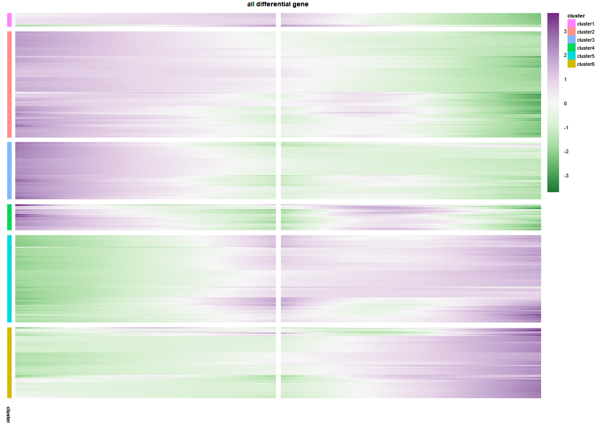

```r
# generate smooth activity matrix
diff_gene_res <- act_patternRes %>% filter(p.adjust<0.05)
ysmooth_activity_lineage_1_scale <- t(apply(ysmooth_activity_lineage_1_mat ,1,function(x){x-x[1]}))
ysmooth_activity_lineage_2_scale <- t(apply(ysmooth_activity_lineage_2_mat,1,function(x){x-x[1]}))
diff_gene_matrix <- cbind(ysmooth_activity_lineage_1_scale[row.names(diff_gene_res), rev(colnames(ysmooth_activity_lineage_1_scale))], ysmooth_activity_lineage_2_scale[row.names(diff_gene_res),])

# heatmap
library(pheatmap)
library(RColorBrewer)
cols <- rev(brewer.pal(9, "PRGn"))
#cols <- c("#1565c0","white","#c62828")
pal <- colorRampPalette(cols)(100)
cluster_num <- 6
p <- pheatmap(mat = diff_gene_matrix,scale="row", cluster_cols = F, clustering_method = "ward.D2", cutree_rows = cluster_num, fontsize = 4, color = pal, show_rownames = F, show_colnames = F, silent=T,gaps_col=100)
#------how to change cluster order
hclust.result<-p$tree_row
cluster = cutree(hclust.result,k=cluster_num)
cluster_name = paste("C",cluster,sep="")
names(cluster_name) = names(cluster)
hclust.result.order<-p$tree_row$order
cluster_name_ordered = cluster_name[hclust.result.order]
cluster_categroy = unique(cluster_name_ordered)
new_cluster_name = paste("cluster",1:length(cluster_categroy),sep="")
names(new_cluster_name) = cluster_categroy
anno_row = data.frame(cluster = cluster_name_ordered)
anno_row$cluster = new_cluster_name[as.character(anno_row$cluster)]
anno_row$cluster = factor(anno_row$cluster,
levels = paste("cluster",1:cluster_num,sep=""))

#---get all differential gene heatmap by cluster
diff_gene_matrix_ordered <- diff_gene_matrix[row.names(anno_row),]
p <- pheatmap(mat = diff_gene_matrix_ordered, scale="row", cluster_cols = F, cluster_rows = F, cutree_rows = cluster_num, fontsize = 4, color = pal, show_rownames = F, show_colnames = F, annotation_row = anno_row, main = "all differential gene", gaps_row = cumsum(table(anno_row$cluster)), gaps_col = 100)
p
```

We using unsupervised hierarchical clustering method to cluster these differential TFs and seperated them into 6 patterns. Each pattern represent a group of TFs that share similar dynamic activities. Moreover, these regulons may have divergent function between HECs and lateAECs. Next, we estimate the average activity of TFs in each group and visualize them with curves.

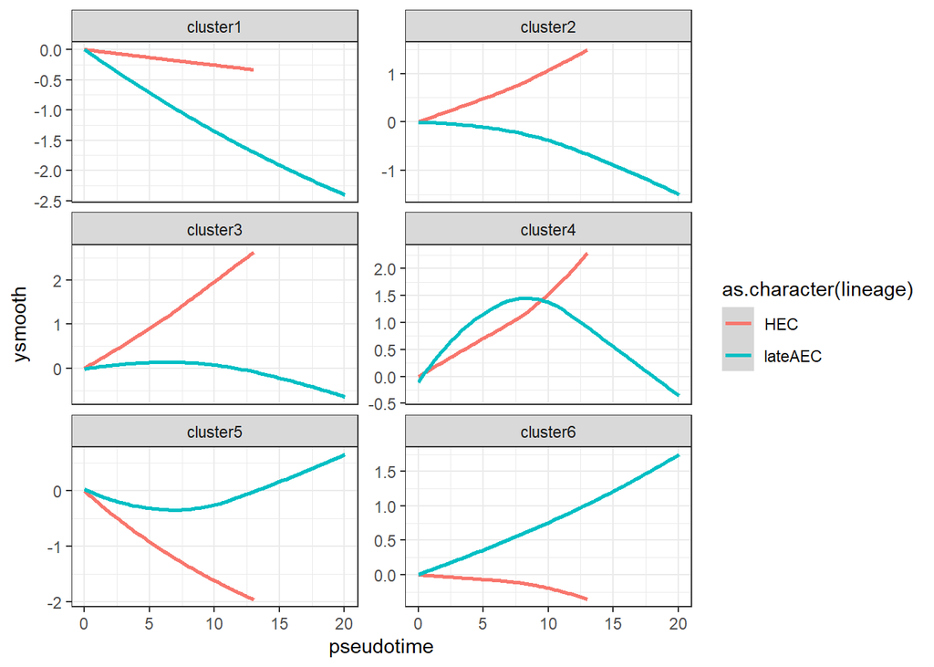

```r
diff_gene_mean <- apply(diff_gene_matrix_ordered,2,function(x){tapply(x,anno_row[names(x),1],median)})
diff_gene_mean_lineage1 <- diff_gene_mean[,1:100]
diff_gene_mean_lineage1_frm <- reshape2::melt(data = diff_gene_mean_lineage1)
diff_gene_mean_lineage1_frm$lineage <- rep(1,nrow(diff_gene_mean_lineage1_frm))
diff_gene_mean_lineage2 <- diff_gene_mean[,101:200]
diff_gene_mean_lineage2_frm <- reshape2::melt(data = diff_gene_mean_lineage2)
diff_gene_mean_lineage2_frm$lineage <- rep(2,nrow(diff_gene_mean_lineage2_frm))
diff_gene_mean_tbl <- rbind(diff_gene_mean_lineage1_frm, diff_gene_mean_lineage2_frm)
colnames(diff_gene_mean_tbl)[1:3] <- c("cluster","pseudotime","ysmooth")
diff_gene_mean_tbl$lineage <- ifelse(diff_gene_mean_tbl$lineage==1,"HEC","lateAEC")

library(ggplot2)
l <- ggplot(data = diff_gene_mean_tbl, mapping = aes(x=pseudotime, y= ysmooth, color=as.character(lineage), group=lineage))+
  geom_smooth()+
  facet_wrap(.~cluster, scales = "free_y", ncol=2)+
  theme_bw()
l
```

#### 2.2 Correlations between TF activity and TF expression

In this section, we evaluated the correlations between TF activity and TF expression in different patterns.

```r
# create the expression level object
exp_mat <- assay(atfr,"logcounts")[row.names(diff_gene_res),]
exp_sce <- fitGAM(counts = exp_mat, pseudotime = cell_pseudotime, cellWeights = cell_weight)
# smooth gene expression
ysmooth_expression <- predictSmooth(models = exp_sce, gene = row.names(exp_sce), nPoints = 100)
# get two lineage dynamic expression level
ysmooth_expression_lineage_1 <- ysmooth_expression %>% filter(lineage==1)
ysmooth_expression_lineage_1_tbl <- reshape2::dcast(data = ysmooth_expression_lineage_1[,-1], formula = gene~time)
ysmooth_expression_lineage_1_mat <- as.matrix(ysmooth_expression_lineage_1_tbl[,-1])
row.names(ysmooth_expression_lineage_1_mat) <- ysmooth_expression_lineage_1_tbl$gene

ysmooth_expression_lineage_2 <- ysmooth_expression %>% filter(lineage==2)
ysmooth_expression_lineage_2_tbl <- reshape2::dcast(data = ysmooth_expression_lineage_2[,-1], formula = gene~time)
```

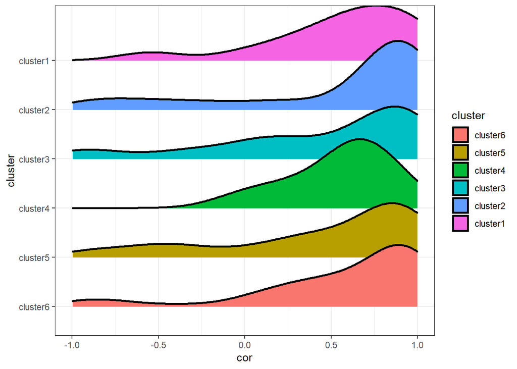

```r
ysmooth_expression_lineage_2_mat <- as.matrix(ysmooth_expression_lineage_2_tbl[,-1])
row.names(ysmooth_expression_lineage_2_mat) <- ysmooth_expression_lineage_2_tbl$gene

ysmooth_expression_lineage_1_scale <- t(apply(ysmooth_expression_lineage_1_mat ,1,function(x){x-x[1]}))
ysmooth_expression_lineage_2_scale <- t(apply(ysmooth_expression_lineage_2_mat,1,function(x){x-x[1]}))
diff_gene_exp_matrix <- cbind(ysmooth_expression_lineage_1_scale[row.names(diff_gene_res), rev(colnames(ysmooth_expression_lineage_1_scale))], ysmooth_expression_lineage_2_scale[row.names(diff_gene_res),])

# calculate the collection coefficient between activity level and expression level.
cor_val <- c()
for(i in row.names(diff_gene_res)){
  cor_i <- cor(diff_gene_matrix[i,],diff_gene_exp_matrix[i,])
  cor_val[i] <- cor_i
}

# merge TFs with cluster and correlation information
diff_gene_cor_tbl <- data.frame(anno_row,cor=cor_val[row.names(anno_row)])
diff_gene_cor_tbl$cluster <- factor(diff_gene_cor_tbl$cluster,levels = rev(levels(diff_gene_cor_tbl$cluster)))
library(ggridges)
d <- ggplot(data = diff_gene_cor_tbl, mapping = aes(x=cor, y=cluster, fill=cluster))+
  geom_density_ridges_gradient(size = 1, scale = 1.4, panel_scaling = F, alpha=.8,na.rm=T)+
  scale_x_continuous(limits = c(-1,1))+
  theme_bw()
d
```

We found that most differential TFs showed relatively high correlation between expression and activity level. However, TFs in some clusters showed relatively low correlations, indicating that TFs in these two clusters may showed some controversial functions. For example, the target genes of these TFs may be repressed. Collectively, activity level analysis is more likely to identify more TFs that potentially regulate the cell fate decision.